# **A quantitative analysis of classical denoising methods**

```python
import matplotlib.pyplot as plt
plt.rcParams['savefig.dpi'] = 100
import numpy as np
import scipy.signal
from scipy.fft import fft, ifft
from scipy.ndimage import correlate
import cv2
import bm3d
import pywt
```

Let $i$ be a grayscale image with power $P_i$.

[figure not shown]

```python
img = plt.imread('lena.png')
plt.imshow(img, cmap='grey')
```

This image is degraded by additive Gaussian noise, independent of the image content, whose power is set to achieve a target SNR of 15 dB. We denote the resulting noisy image by $i_b$.

The noise power (equivalently, its variance $\sigma^2$) is derived from the SNR definition:

$$P_n = \frac{P_i}{10^{\text{SNR}/10}}$$

The following function generates the noisy image $i_b$.

```python
# Image degradation with an additive gaussian noise and a fixed SNR
def gen_noised(img, SNR):
  # Image power
  ps_i = np.mean(np.square(img))

  # Noise variance
  noise_variance = ps_i / (10 ** (SNR / 10))
  noise_std = np.sqrt(noise_variance)

  gaussian_noise = np.random.normal(0, noise_std, img.shape)
  return img + gaussian_noise, noise_std
```

```python
noised, std = gen_noised(img, 15)
```

We display the original image and its degraded version.

```
(np.float64(-0.5), np.float64(511.5), np.float64(511.5), np.float64(-0.5))
```

[figure not shown]

```python
plt.figure(figsize=(12, 6))

plt.subplot(1, 2, 1)
plt.imshow(img, cmap='gray')
plt.title("Original image (i)")
plt.axis("off")

plt.subplot(1, 2, 2)
plt.imshow(noised, cmap='gray')
plt.title("Noisy image (ib), SNR = 15 ")
plt.axis("off")
```

We then display the degraded image with SNR varying from 0 dB to 50 dB.

[figure not shown]

```python
snr_values = [0, 5, 15, 30, 50]

fig, axes = plt.subplots(1, len(snr_values), figsize=(12, 6))

for i, snr in enumerate(snr_values):
    noisy_image, _ = gen_noised(img, snr)
    axes[i].imshow(noisy_image, cmap='gray')
    axes[i].set_title(f'SNR = {snr} dB')
    axes[i].axis('off')

plt.tight_layout()
plt.show()
```

The noise level decreases as the SNR increases; beyond 30 dB, no significant difference is observed anymore, which is expected since the SNR defines the ratio between the image power and the noise power.

We now consider a noisy image $i_b$ corrupted by Gaussian noise at 20 dB. We denoise this image using several classical methods. For each method, in addition to visual assessment, we consider two quantitative criteria: the Mean Squared Error (MSE) and the Peak Signal-to-Noise Ratio (PSNR) between the estimated image and the original image $i$. For each method, we attempt to tune the respective hyperparameters to their optimal values.

##### **2D Gaussian Linear Filtering**

```python
img = plt.imread('lena.png')
```

```python
noised, std = gen_noised(img, 20)
```

[figure not shown]

```python
plt.imshow(noised, cmap="gray")
```

We consider $x$, the estimator of the noise-free image $x_0$, of size $N$. It depends only on the observation $y$ (the noisy image), making it a random vector that depends on the noise $w$.

A shift-invariant linear denoiser is a convolution with a kernel $h$:

$$x = y * h$$

We therefore compute the convolution between the noisy image and the kernel.

```python
cconv = lambda a,b : np.real(np.fft.ifft2(np.fft.fft2(a)*np.fft.fft2(b)))
```

```python
norm = lambda h: h/np.sum(h)
size = noised.size
```

```python
# Grid centered on 0
t_row = np.concatenate((np.arange(0, noised.shape[0]//2), np.arange(-noised.shape[0]//2, 0)))
t_col = np.concatenate((np.arange(0, noised.shape[1]//2), np.arange(-noised.shape[1]//2, 0)))
X, Y = np.meshgrid(t_col, t_row)

# Gaussian filter
mu = 10 # Gaussian filter standard deviation
h = np.exp(-(X**2 + Y**2) / (2 * mu**2)) # Gaussian filter centered on origin
h = norm(h) # Sum of filter values equals to 1

# Fourier Transform of the filter
H = np.fft.fft2(h) #2DFFT of the filter
H_shifted = np.fft.fftshift(np.real(H)) #2DFFT of the shifted filter (low frequencies at the center)
```

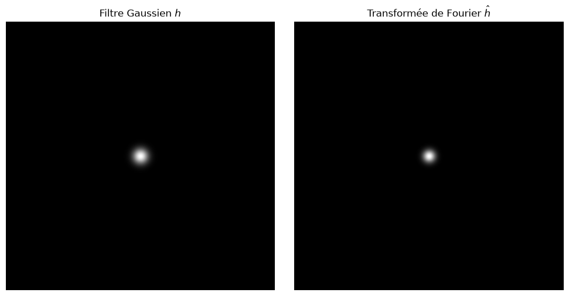

```python
# Plotting the results
fig, axes = plt.subplots(1, 2, figsize=(10, 5))

# Plotting the gaussian filter
axes[0].imshow(np.fft.fftshift(h), cmap='gray')
axes[0].set_title("Filtre Gaussien $h$")
axes[0].axis("off")

# Plotting the Fourier Transform
axes[1].imshow(H_shifted, cmap='gray')
axes[1].set_title("Transformée de Fourier $\hat{h}$")
axes[1].axis("off")

plt.tight_layout()
plt.show()
```

```python
denoised = cconv(noised, h)
```

[figure not shown]

```python
plt.imshow(denoised, cmap="gray")
```

To find the optimal hyperparameter ($μ$, the standard deviation of the Gaussian filter), we use an approach based on MSE and PSNR, testing several values and selecting the one that minimizes the error or maximizes the PSNR.

```python
#Conversion to integers and normalization
noised = noised * 255
noised = np.clip(noised, 0, 255)
noised = np.round(noised).astype(np.uint8)

img = img * 255
img = np.clip(img, 0, 255)
img = np.round(img).astype(np.uint8)

print(noised.dtype)
print(img.dtype)
```

```
uint8
uint8
```

```python
def compute_mse_psnr(original, estimated):

    mse = np.mean((original - estimated) ** 2)

    if mse == 0:
        return mse, float('inf')  # Avoids division by 0

    max_pixel = 255 if original.dtype == np.uint8 else 1.0
    psnr = 10 * np.log10((max_pixel ** 2) / mse)

    return mse, psnr
```

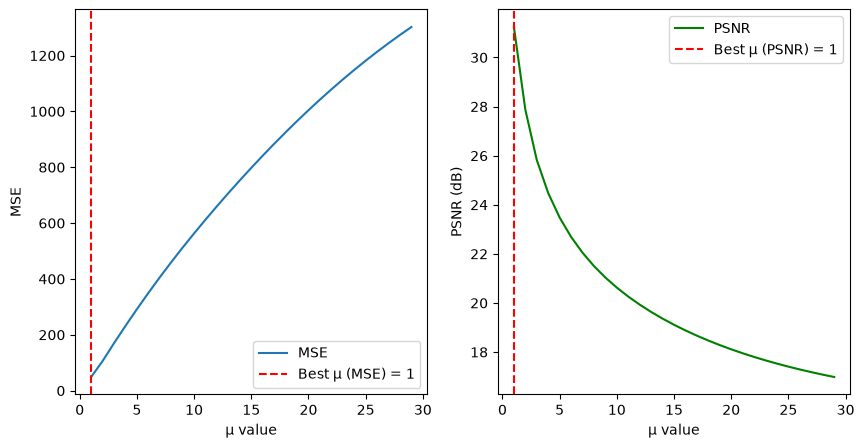

```
Best MSE = 48.85600183188176
Best μ (MSE) = 1
Best μ (PSNR) = 1
```

```python
# Hyperparameter search for mu
mu_values = np.arange(1, 30, 1)
mse_values, psnr_values = [], []

for mu in mu_values:
    h = np.exp(-(X**2 + Y**2) / (2 * mu**2))  # Gaussian filter centered at the origin
    h = norm(h)  # Filter values sum to 1
    denoised = cconv(noised, h)  # Denoising
    mse, psnr = compute_mse_psnr(img, denoised)  # Evaluation
    mse_values.append(mse)
    psnr_values.append(psnr)

# Selecting the optimal mu
best_mu_mse = mu_values[np.argmin(mse_values)]   # Minimizes MSE
best_mu_psnr = mu_values[np.argmax(psnr_values)]  # Maximizes PSNR

# Plotting the results
plt.figure(figsize=(10, 5))
plt.subplot(1, 2, 1)
plt.plot(mu_values, mse_values, label="MSE")
plt.axvline(best_mu_mse, color='r', linestyle="--", label=f"Best μ (MSE) = {best_mu_mse}")
plt.xlabel("μ value")
plt.ylabel("MSE")
plt.legend()

plt.subplot(1, 2, 2)
plt.plot(mu_values, psnr_values, label="PSNR", color="g")
plt.axvline(best_mu_psnr, color='r', linestyle="--", label=f"Best μ (PSNR) = {best_mu_psnr}")
plt.xlabel("μ value")
plt.ylabel("PSNR (dB)")
plt.legend()

plt.show()

print(f"Best MSE = {mse_values[np.argmin(mse_values)]}")
print(f"Best μ (MSE) = {best_mu_mse}")
print(f"Best μ (PSNR) = {best_mu_psnr}")
```

The best value found for mu is 1. Note that this coincides with the lower bound of the tested grid (1 to 30), and both curves are strictly monotonic over this range, so a finer search below 1 would be needed to confirm this is a true optimum rather than an artifact of the search range.

```python
# Gaussian filter
mu = best_mu_psnr  # Standard deviation of the Gaussian filter
h = np.exp(-(X**2 + Y**2) / (2 * mu**2))  # Gaussian filter centered at the origin
h = norm(h)  # Filter values sum to 1
```

[figure not shown]

```
MSE: 48.85600183188176
PSNR: 31.241624375959983 dB
```

```python
denoised = cconv(noised, h)

fig, axes = plt.subplots(1, 3, figsize=(12, 6))

# Original image
axes[0].imshow(img, cmap='gray')
axes[0].set_title("Original image")
axes[0].axis("off")

# Noisy image
axes[1].imshow(noised, cmap='gray')
axes[1].set_title("Noisy image")
axes[1].axis("off")

# Denoised image
axes[2].imshow(denoised, cmap='gray')
axes[2].set_title(f"Denoised image, mu = {best_mu_psnr}")
axes[2].axis("off")

plt.tight_layout()
plt.show()

mse, psnr = compute_mse_psnr(img, denoised)
print(f"MSE: {mse}")
print(f"PSNR: {psnr} dB")

# Saved for later comparison
denoised_gaussian = denoised
```

Linear denoising with a Gaussian filter effectively reduces noise, but tends not to preserve edges. It smooths the image because it does not account for intensity similarity between pixels, nor whether a given pixel lies on an edge.

##### **Bilateral Filtering**

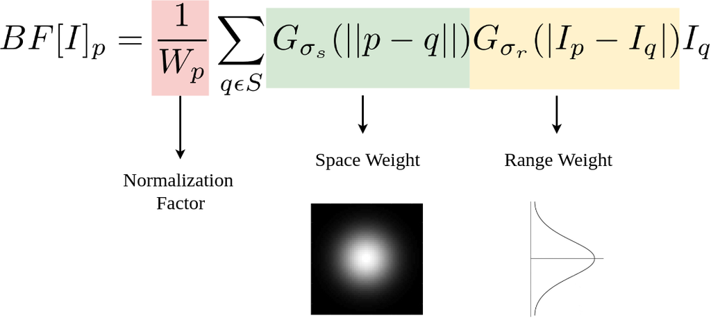

The bilateral filter takes into account both the spatial distance and the intensity similarity between neighboring pixels.

It relies on two components:

- **Spatial weighting**: as in a Gaussian filter, pixels close to a central pixel are weighted more strongly according to a Gaussian function of their spatial distance. This reduces the influence of distant pixels.
- **Intensity (range) weighting**: this component accounts for the difference in intensity between pixels. If two pixels are spatially close but have very different intensities, their mutual influence is reduced. This is what allows the filter to preserve edges, where sharp intensity transitions occur.

Formally, the filtered value at pixel $x$ is:

$$ I_{\text{filtered}}(x) = \frac{1}{W_p} \sum_{x_i \in \Omega} I(x_i) \cdot g_s(\|x_i - x\|) \cdot f_r(\|I(x_i) - I(x)\|) $$

- $g_s$, the **spatial weight**, is a Gaussian applied to the spatial distance. A larger $\sigma_s$ means that distant pixels can still influence each other, as long as their intensities remain close.
- $f_r$, the **range weight**, is a Gaussian applied to the intensity difference. A larger $\sigma_r$ means that pixels with more different intensities will still be averaged together.
- $W_p$ is a normalization factor ensuring that the weights sum to 1.

This denoising method therefore has two hyperparameters to tune: the standard deviations of the two Gaussians, $\sigma_s$ and $\sigma_r$.

```python
"""
Bilateral filtering

Hyperparameters:
  - sigma_space: standard deviation of the spatial Gaussian (neighborhood extent)
  - sigma_color: standard deviation of the intensity (range) Gaussian

Parameters:
  - src: noisy input image
  - d: diameter of the pixel neighborhood used during filtering
  - sigmaColor: standard deviation for the "range weight" Gaussian ($\\sigma_r$)
  - sigmaSpace: standard deviation for the "space weight" Gaussian ($\\sigma_s$)
"""
denoised = cv2.bilateralFilter(noised, d=15, sigmaColor=50, sigmaSpace=50)
```

[figure not shown]

```python
fig, axes = plt.subplots(1, 3, figsize=(12, 6))

#Original image
axes[0].imshow(img, cmap='gray')
axes[0].set_title("Original image")
axes[0].axis("off")

#Noisy ilage
axes[1].imshow(noised, cmap='gray')
axes[1].set_title("Noisy image")
axes[1].axis("off")

#Denoised image
axes[2].imshow(denoised, cmap='gray')
axes[2].set_title(f"Denoised image, mu = {best_mu_psnr}")
axes[2].axis("off")

plt.tight_layout()
plt.show()
```

Here, we chose a neighborhood diameter of 15 pixels for the filtering window, along with standard deviations of 50 for both Gaussians. We observe that this effectively removes noise but destroys structural detail. We now optimize the bilateral filter's hyperparameters using MSE and PSNR.

```python
def optimize_bilateral_filter(noised_img, original_img,
                               d_values, sigma_values):

    best_mse = float('inf')
    best_psnr = -float('inf')
    best_params = (None, None)
    best_denoised = None

    all_mse = []
    all_psnr = []
    all_params = []

    for d in d_values:
        for sigma in sigma_values:

            denoised = cv2.bilateralFilter(noised_img, d, sigma, sigma)

            mse, psnr = compute_mse_psnr(original_img, denoised)

            all_mse.append(mse)
            all_psnr.append(psnr)
            all_params.append((d, sigma))

            # Selection criterion: minimize MSE (equivalently, maximize PSNR)
            # We use MSE as the primary reference here
            if mse < best_mse:
                best_mse = mse
                best_psnr = psnr
                best_params = (d, sigma)
                best_denoised = denoised

    return best_params, best_denoised, best_mse, all_mse, best_psnr, all_psnr, all_params
```

```
uint8
uint8
```

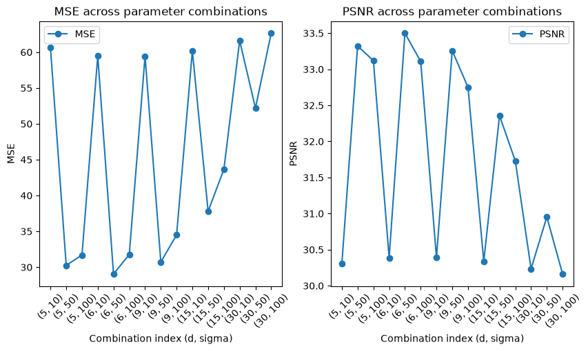

```
Best hyperparameters (d, sigma): (6, 50)
MSE: 29.04532241821289
PSNR: 33.50004159133867
```

[figure not shown]

```python
d_values = [5, 6, 9, 15, 30]  # Neighborhood diameters
print(noised.dtype)
print(img.dtype)

# I had originally defined a function taking two separate lists (one per Gaussian),
# but empirically found that using the same standard deviation for both gives
# better results.
# sigmaColor_values = [10, 50, 100]  # sigmaColor (range-weight Gaussian std)
# sigmaSpace_values = [10, 50, 100]  # sigmaSpace (space-weight Gaussian std)

sigma_values = [10, 50, 100]

best_params, best_denoised, best_mse, all_mse, best_psnr, all_psnr, all_params = optimize_bilateral_filter(
        noised,
        img,
        d_values,
        sigma_values,
    )

# Plotting the results
plt.figure(figsize=(10, 5))
plt.subplot(1, 2, 1)
plt.plot(all_mse, label="MSE", marker='o')
plt.title("MSE across parameter combinations")
plt.xlabel("Combination index (d, sigma)")
plt.ylabel("MSE")
plt.xticks(range(len(all_params)), all_params, rotation=45)
plt.legend()

plt.subplot(1, 2, 2)
plt.plot(all_psnr, label="PSNR", marker='o')
plt.title("PSNR across parameter combinations")
plt.xlabel("Combination index (d, sigma)")
plt.ylabel("PSNR")
plt.xticks(range(len(all_params)), all_params, rotation=45)
plt.legend()

plt.show()

print("Best hyperparameters (d, sigma):", best_params)
print("MSE:", best_mse)
print("PSNR:", best_psnr)

fig, axes = plt.subplots(1, 3, figsize=(12, 6))

# Original image
axes[0].imshow(img, cmap='gray')
axes[0].set_title("Original image")
axes[0].axis("off")

# Noisy image
axes[1].imshow(noised, cmap='gray')
axes[1].set_title("Noisy image")
axes[1].axis("off")

# Denoised image
axes[2].imshow(best_denoised, cmap='gray')
axes[2].set_title(f"Denoised image (bilateral filter), d = {best_params[0]}, sigma = {best_params[1]}")
axes[2].axis("off")

plt.tight_layout()
plt.show()

# Saved for later comparison
denoised_bilateral = best_denoised
```

##### **Non-Local Means Filtering**

The previous approaches remove only a limited amount of noise. They work by applying operations such as averaging the values within a neighborhood around a pixel to replace the value of the central element. These are therefore limited approaches, where denoising is **local** to the pixel's neighborhood.

Noise is often a zero-mean random signal, which means that averaging several images of the same scene can reduce its impact. A simple experiment consists of capturing several static images and computing their average to observe a reduction in noise. However, this approach fails if the camera or the scene moves, and it cannot be used when only a single image is available.

The key idea is therefore to exploit redundancy within a single image: instead of searching for information only in the immediate neighborhood, we can identify similar regions elsewhere in the image and use them to smooth out noise while preserving fine details.

```python
# Non-Local Means (NLM) denoising

"""
Parameters:
  src: noisy input image
  dst: output image
  templateWindowSize: size in pixels of the template patch used to compute weights.
                       Must be odd. Recommended value: 7
  searchWindowSize: size in pixels of the window used to compute the weighted
                     average for a given pixel. Must be odd. Affects performance
                     linearly. Recommended value: 21
  h: parameter controlling the strength of the filter. A large h removes noise
     more aggressively but also destroys fine detail.
"""
print(noised.dtype)
# Recommended values
denoised = cv2.fastNlMeansDenoising(noised, None, h=10, templateWindowSize=7, searchWindowSize=21)
```

```
uint8
```

[figure not shown]

```python
fig, axes = plt.subplots(1, 3, figsize=(12, 6))

# Original image
axes[0].imshow(img, cmap='gray')
axes[0].set_title("Original image")
axes[0].axis("off")

# Noisy image
axes[1].imshow(noised, cmap='gray')
axes[1].set_title("Noisy image")
axes[1].axis("off")

# Denoised image
axes[2].imshow(denoised, cmap='gray')
axes[2].set_title("Denoised image (NLM), \n h = 10, templateWindowSize = 7, searchWindowSize = 21")
axes[2].axis("off")

plt.tight_layout()
plt.show()
```

NLM can remove noise almost entirely; the h parameter just needs to be calibrated to avoid over-smoothing the image. 10 appears to be a good starting value.

```python
def optimize_nlm_filter(noised_img, original_img, h_values, templateWindowSize_values, searchWindowSize_values):
    best_mse = float('inf')
    best_psnr = -float('inf')
    best_params = (None, None, None)
    best_denoised = None

    all_mse = []
    all_psnr = []
    all_params = []

    for h in h_values:
        for templateWindowSize in templateWindowSize_values:
            for searchWindowSize in searchWindowSize_values:
                # Apply NLM denoising
                denoised = cv2.fastNlMeansDenoising(noised_img, None, h, templateWindowSize, searchWindowSize)
                mse, psnr = compute_mse_psnr(original_img, denoised)

                all_mse.append(mse)
                all_psnr.append(psnr)
                all_params.append((h, templateWindowSize, searchWindowSize))

                # We aim to minimize MSE (equivalently, maximize PSNR)
                if mse < best_mse:
                    best_mse = mse
                    best_psnr = psnr
                    best_params = (h, templateWindowSize, searchWindowSize)
                    best_denoised = denoised

    return best_params, best_denoised, best_mse, all_mse, best_psnr, all_psnr, all_params
```

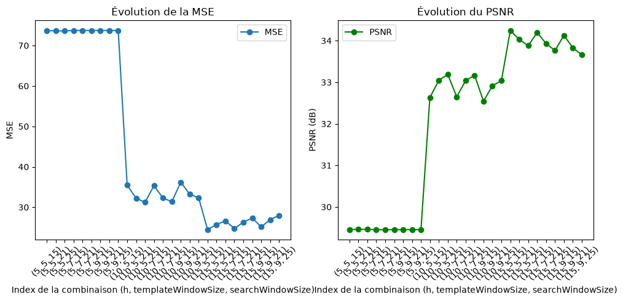

```
Meilleurs hyperparamètres (h, templateWindowSize, searchWindowSize) : (15, 5, 15)
MSE : 24.461410522460938
PSNR : 34.245988646492734
```

[figure not shown]

```python
h_values = [5, 10, 15] #Force du filtrage
templateWindowSize_values = [5, 7, 9] #Taille de la fenêtre de comparaison
searchWindowSize_values = [15, 21, 25] #Taille de la fenêtre de recherche

best_params, best_denoised, best_mse, all_mse, best_psnr, all_psnr, all_params = optimize_nlm_filter(
    noised,
    img,
    h_values,
    templateWindowSize_values,
    searchWindowSize_values
)

# Affichage des courbes de la MSE et du PSNR en fonction des combinaisons testées
plt.figure(figsize=(10, 5))
plt.subplot(1, 2, 1)
plt.plot(all_mse, label="MSE", marker='o')
plt.title("Évolution de la MSE")
plt.xlabel("Index de la combinaison (h, templateWindowSize, searchWindowSize)")
plt.ylabel("MSE")
plt.xticks(range(len(all_params)), all_params, rotation=45)
plt.legend()

plt.subplot(1, 2, 2)
plt.plot(all_psnr, label="PSNR", marker='o', color='g')
plt.title("Évolution du PSNR")
plt.xlabel("Index de la combinaison (h, templateWindowSize, searchWindowSize)")
plt.ylabel("PSNR (dB)")
plt.xticks(range(len(all_params)), all_params, rotation=45)
plt.legend()

plt.tight_layout()
plt.show()

print("Meilleurs hyperparamètres (h, templateWindowSize, searchWindowSize) :", best_params)
print("MSE :", best_mse)
print("PSNR :", best_psnr)

# Affichage comparatif des images
fig, axes = plt.subplots(1, 3, figsize=(12, 6))

# Image originale
axes[0].imshow(img, cmap='gray')
axes[0].set_title("Image originale")
axes[0].axis("off")

# Image bruitée
axes[1].imshow(noised, cmap='gray')
axes[1].set_title("Image bruitée")
axes[1].axis("off")

# Image débruitée par NLM
axes[2].imshow(best_denoised, cmap='gray')
axes[2].set_title(f"Image débruitée (NLM)\nParamètres: h = {best_params[0]}, templateWindowSize = {best_params[1]}, searchWindowSize = {best_params[2]}")
axes[2].axis("off")

plt.tight_layout()
plt.show()

# Sauvegarde pour comparaison ultérieure
denoised_nlm = best_denoised
```

##### **Block-Matching and 3D Filtering (BM3D)**

Avec Hard-Thresholding

```python
#Paramètres :
#image bruitée,
#écart type du bruit (ici multiplié par 255 car std avait été calculé sur une image en float)
denoised = bm3d.bm3d(noised, sigma_psd=std*255, stage_arg=bm3d.BM3DStages.HARD_THRESHOLDING)
```

[figure not shown]

```
MSE : 24.871456056682007
PSNR : 34.17379149829103
```

```python
# Affichage comparatif des images
fig, axes = plt.subplots(1, 3, figsize=(12,6))

# Image originale
axes[0].imshow(img, cmap='gray')
axes[0].set_title("Image originale")
axes[0].axis("off")

# Image bruitée
axes[1].imshow(noised, cmap='gray')
axes[1].set_title("Image bruitée")
axes[1].axis("off")

# Image débruitée par BM3D Hard-thresholding
axes[2].imshow(denoised, cmap='gray')
axes[2].set_title(f"Image débruitée (BM3D Hard-Thresholding)")
axes[2].axis("off")

plt.tight_layout()
plt.show()

mse, psnr = compute_mse_psnr(img, denoised)
print(f"MSE : {mse}")
print(f"PSNR : {psnr}")
```

Avec Hard-Thresholding + Wiener (All stages)

```python
#Paramètres :
#image bruitée,
#écart type du bruit
denoised = bm3d.bm3d(noised, sigma_psd=std*255, stage_arg=bm3d.BM3DStages.ALL_STAGES)
```

[figure not shown]

```
MSE : 22.084005224548463
PSNR : 34.6900251965609
```

```python
# Affichage comparatif des images
fig, axes = plt.subplots(1, 3, figsize=(12, 6))

# Image originale
axes[0].imshow(img, cmap='gray')
axes[0].set_title("Image originale")
axes[0].axis("off")

# Image bruitée
axes[1].imshow(noised, cmap='gray')
axes[1].set_title("Image bruitée")
axes[1].axis("off")

# Image débruitée par BM3D Hard-thresholding + Wiener
axes[2].imshow(denoised, cmap='gray')
axes[2].set_title(f"Image débruitée (BM3D Hard-Thresholding + Wiener)")
axes[2].axis("off")

plt.tight_layout()
plt.show()

mse, psnr = compute_mse_psnr(img, denoised)
print(f"MSE : {mse}")
print(f"PSNR : {psnr}")

#Sauvegarde pour analyse ultérieure
denoised_bm3d = denoised
```

**Comparaison des résultats**

Voici la comparaison qualitative et quantitative des résultats des différentes méthodes de débruitage.

[figure not shown]

```python
# Affichage comparatif des images
fig, axes = plt.subplots(2, 3, figsize=(15, 10))

axes = axes.ravel()

images = [
    (img, "Image originale"),
    (noised, "Image bruitée, SNR = 15 dB"),
    (denoised_gaussian, "Image débruitée (Filtre Gaussien 2D)"),
    (denoised_bilateral, "Image débruitée (Filtrage bilatéral)"),
    (denoised_nlm, "Image débruitée (NLM)"),
    (denoised_bm3d, "Image débruitée (BM3D)")
]

for ax, (image, title) in zip(axes, images):
    ax.imshow(image, cmap='gray')
    ax.set_title(title)
    ax.axis("off")

plt.tight_layout()
plt.show()
```

**L'image issue du débruitage par BM3D semble la plus fidèle à l'image originale. Les structures et détails sont relativement bien conservés tandis que le bruit a totalement disparu.**

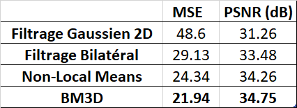

**BM3D atteint la meilleure valeur de MSE et de PSNR (les résultats sont susceptibles de varier légèrement selon l'exécution)**

**Débruitage par décomposition dyadique, décomposition dyadique et seuillage**

**Question 3)a)**

[figure not shown]

```python
#Génération d'une image sparse
h, w = 512, 512
sparse = np.zeros((h, w), dtype=np.uint8)

num_points = 5000  #Nombre de pixels non nuls
x_coords = np.random.randint(0, w, num_points)
y_coords = np.random.randint(0, h, num_points)
sparse[y_coords, x_coords] = 255

#Ici l'image est sparse donc on doit considérer seulement les pixels non-nuls
snr = 20

#Bruitage de l'image sparse
signal_power = np.mean(sparse[sparse > 0] ** 2) if np.any(sparse > 0) else 1
snr_linear = 10 ** (snr / 10.0)
noise_power = signal_power / snr_linear
noise = np.random.normal(0, np.sqrt(noise_power), sparse.shape)
noisy_image = sparse + noise
std_ys = np.sqrt(noise_power)

ys = np.clip(noisy_image, 0, 255).astype(np.uint8)

# mse, psnr = compute_mse_psnr(sparse, ys)
# print(f"MSE: {mse}, PSNR: {psnr}")

#Bruitage de l'image en niveaux de gris
img = plt.imread('lena.png')
yx, std_yx = gen_noised(img, snr)
yx = yx * 255
yx = np.clip(yx, 0, 255)
yx = np.round(yx).astype(np.uint8)

fig, ax = plt.subplots(2, 3, figsize=(12, 6))
ax[1, 2].axis("off")

ax[0, 0].imshow(ys, cmap="gray")
ax[0, 0].set_title(f"Image sparse, {num_points} points")
ax[0, 0].axis("off")

ax[0, 1].imshow(ys, cmap="gray")
ax[0, 1].set_title(f"Image sparse bruitée, bruit gaussien {snr} db (ys = s + b)")
ax[0, 1].axis("off")

ax[0, 2].imshow(noisy_image - sparse, cmap='gray')
ax[0, 2].set_title("Différence (bruit ajouté)")
ax[0, 2].axis("off")

ax[1, 0].imshow(img, cmap="gray")
ax[1, 0].set_title("Image x")
ax[1, 0].axis("off")

ax[1, 1].imshow(yx, cmap="gray")
ax[1, 1].set_title(f"Image x bruitée, bruit gaussien {snr} (yx = x + b)")
ax[1, 1].axis("off")


plt.tight_layout()
plt.show()
```

**Question 3)b) Débruitage par seuillage doux**

Lorsque l'on a une image parcimonieuse (sparse) on veut exploiter cette parcimonie parce qu'elle permet une meilleure séparation image/bruit.

On sait que la solution de l'estimateur MAP pour le modèle de bruit additif y = x + n, sous l'hypothèse que l'image x est sparse et que le bruit n est gaussien, correspond à un seuillage doux lorsque l'on suppose une prior Laplacienne sur les coefficients de x.

**Débruitage de l'image sparse**

```python
#Seuillage doux pour image sparse
def soft_thresholding_sparse(img, T):
    img = img.astype(np.float32)
    result = img.copy()
    mask = img > 0

    #Seuillage doux sur les pixels non nuls
    result[mask] = np.sign(img[mask]) * np.maximum(np.abs(img[mask]) - T, 0)

    return np.clip(result, 0, 255).astype(np.uint8)

#Seuillage dur pour image sparse
def hard_thresholding_sparse(img, T):
    img = img.astype(np.float32)
    mask = img > 0

    img[mask] = img[mask] * (np.abs(img[mask]) > T)
    return img.astype(np.uint8)
```

```
MSE: 0.046169281005859375, PSNR: 61.48727249531392
```

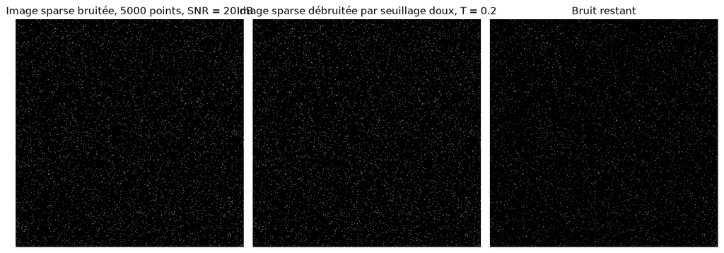

```python
#Calcul du seuil basé sur l'écart-type du bruit
T = 2 * std_ys #Choix empirique

#Débruitage de ys
ys_denoised = soft_thresholding_sparse(ys, T)

#Affichage
fig, ax = plt.subplots(1, 3, figsize=(12, 6))

ax[0].imshow(ys, cmap="gray")
ax[0].set_title(f"Image sparse bruitée, {num_points} points, SNR = {snr} dB")
ax[0].axis("off")

ax[1].imshow(ys_denoised, cmap="gray")
ax[1].set_title(f"Image sparse débruitée par seuillage doux, T = {T}")
ax[1].axis("off")

ax[2].imshow(sparse - ys_denoised, cmap='gray')
ax[2].set_title("Bruit restant")
ax[2].axis("off")

mse, psnr = compute_mse_psnr(ys_denoised, sparse)
print(f"MSE: {mse}, PSNR: {psnr}")
plt.tight_layout()
plt.show()
```

Le débruitage a bien fonctionné, on a une MSE très basse

**Débruitage de l'image non sparse avec décomposition dyadique en ondelettes**

On applique une transformée en ondelettes à l'image pour obtenir plusieurs sous-bandes de fréquences. Dans ces sous-bandes, les coefficients faibles (souvent du bruit) sont atténués en les réduisant progressivement vers 0. On applique la transformée inverse pour reconstruire l'image débruitée.

La formule du seuillage doux pour un coefficient w est :

**w' = sign(w) * (abs(w) - T) si abs(w) > T et 0 sinon**

où T est un seuil déterminé du bruit et de la distribution des coefficients d'ondelettes, il peut aussi être spécifié directement.

```python
def wavelet(img, ordre):
    N = img.shape[0]
    coeffs = img.copy().astype(np.float64)

    for level in range(ordre):
        current_size = N // (2**level)      #taille de la sous-image courante
        new_size = current_size // 2         #nouvelle taille (approximation)
        temp = coeffs.copy()
        for i in range(new_size):
            for j in range(new_size):
                #indices dans la sous-image
                r = 2 * i
                c = 2 * j
                #extraction des 4 pixels du bloc 2x2
                a = coeffs[r, c]
                b = coeffs[r+1, c]
                c_val = coeffs[r, c+1]
                d = coeffs[r+1, c+1]
                #calcul de l'approx et des détails
                approx = (a + b + c_val + d) / 4.0
                horiz  = (a + b - c_val - d) / 4.0
                vert   = (a - b + c_val - d) / 4.0
                diag   = (a - b - c_val + d) / 4.0
                temp[i, j] = approx
                temp[i + new_size, j] = horiz
                temp[i, j + new_size] = vert
                temp[i + new_size, j + new_size] = diag
        coeffs[:current_size, :current_size] = temp[:current_size, :current_size]
    return coeffs
```

```python
def invwavelet(coeffs, ordre):
    N = coeffs.shape[0]
    img = coeffs.copy().astype(np.float64)

    #recons des niveaux dans l'ordre inverse
    for level in range(ordre, 0, -1):
        current_size = N // (2**(level-1))
        new_size = current_size // 2
        temp = img.copy()
        for i in range(new_size):
            for j in range(new_size):
                #extraction des coeffs d'approx et de détails
                a = temp[i, j]
                b = temp[i + new_size, j]
                c_val = temp[i, j + new_size]
                d = temp[i + new_size, j + new_size]
                #reconstruction inverse de la transformée de Haar
                img[2*i, 2*j]     = a + b + c_val + d
                img[2*i+1, 2*j]   = a + b - c_val - d
                img[2*i, 2*j+1]   = a - b + c_val - d
                img[2*i+1, 2*j+1] = a - b - c_val + d
        #la reconstruction s'applique sur toute la zone de taille current_size
    return np.clip(img, 0, 255).astype(np.uint8)
```

```python
def soft_thresholding(x, T):
    #Seuillage doux des coefficients d'ondelettes
    return np.sign(x) * np.maximum(np.abs(x) - T, 0)

def hard_thresholding(x, T):
    return x * (np.abs(x) > T)

def denoise_wavelet(img, ordre, thresholding, T=None):
    coeffs = wavelet(img, ordre)
    N = img.shape[0]

    #Calcul automatique du seuil à partir de tous les coefficients de détail
    if T is None:
        details = []
        for level in range(1, ordre+1):
            current_size = N // (2**(level-1))
            new_size = current_size // 2
            #coeffs de détails horizontaux
            details.append(coeffs[new_size:current_size, :new_size])
            #coeffs de détails verticaux
            details.append(coeffs[:new_size, new_size:current_size])
            #coeffs de détails diagonaux
            details.append(coeffs[new_size:current_size, new_size:current_size])
        details = np.concatenate([d.flatten() for d in details])
        T = np.median(np.abs(details)) / 0.6745

    coeffs_denoised = coeffs.copy()
    #seuillage pour chaque niveau de détails
    for level in range(1, ordre+1):
        current_size = N // (2**(level-1))
        new_size = current_size // 2
        if thresholding == 'soft':
            coeffs_denoised[new_size:current_size, :new_size] = soft_thresholding(coeffs_denoised[new_size:current_size, :new_size], T)
            coeffs_denoised[:new_size, new_size:current_size] = soft_thresholding(coeffs_denoised[:new_size, new_size:current_size], T)
            coeffs_denoised[new_size:current_size, new_size:current_size] = soft_thresholding(coeffs_denoised[new_size:current_size, new_size:current_size], T)
        elif thresholding == 'hard':
            coeffs_denoised[new_size:current_size, :new_size] = hard_thresholding(coeffs_denoised[new_size:current_size, :new_size], T)
            coeffs_denoised[:new_size, new_size:current_size] = hard_thresholding(coeffs_denoised[:new_size, new_size:current_size], T)
            coeffs_denoised[new_size:current_size, new_size:current_size] = hard_thresholding(coeffs_denoised[new_size:current_size, new_size:current_size], T)
        else:
            raise ValueError("Méthode de seuillage invalide. Utilisez 'soft' ou 'hard'.")

    return invwavelet(coeffs_denoised, ordre)
```

```
Entre image bruitée et image originale : MSE: 17728.375, PSNR: 5.6441144943237305
Entre image débruitée et image originale : MSE: 17389.9765625, PSNR: 5.727813720703125
```

[figure not shown]

```python
ordre = 2 #niveau de décomposition
thresholding = "soft"
yx_denoised = denoise_wavelet(yx, ordre, thresholding)

fig, ax = plt.subplots(1, 3, figsize=(12, 6))

ax[0].imshow(img, cmap="gray")
ax[0].set_title("Image originale")
ax[0].axis("off")

ax[1].imshow(yx, cmap="gray")
ax[1].set_title(f"Image bruitée, bruit gaussien {snr} db")
ax[1].axis("off")

ax[2].imshow(yx_denoised, cmap="gray")
ax[2].set_title("Image débruitée par transformée en ondelettes + " + "\n" + f"{thresholding} thresholding")
ax[2].axis("off")

mse, psnr = compute_mse_psnr(yx, img)
print(f"Entre image bruitée et image originale : MSE: {mse}, PSNR: {psnr}")

mse, psnr = compute_mse_psnr(yx_denoised, img)
print(f"Entre image débruitée et image originale : MSE: {mse}, PSNR: {psnr}")

plt.show()

plt.tight_layout()
plt.show()
```

On observe un léger débruitage, l'augmentation de l'ordre induit un effet de mosaïque.

**Débruitage par seuillage dur**

```
MSE: 0.009082794189453125, PSNR: 68.54860887414692
```

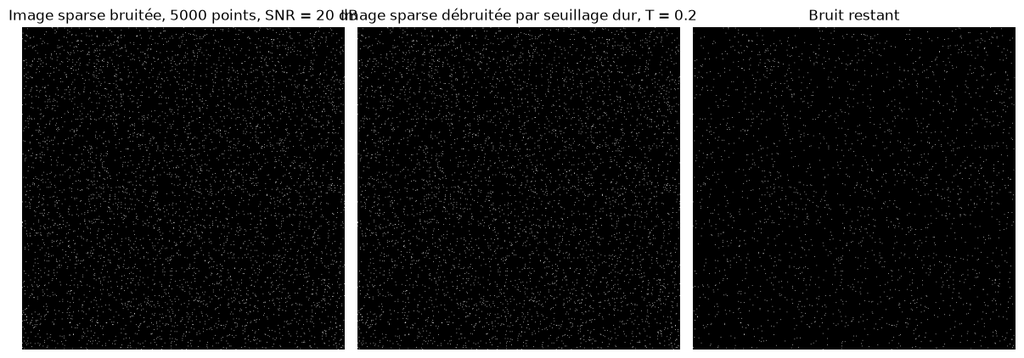

```python
#Calcul du seuil basé sur l'écart-type du bruit
T = 2 * std_ys #Choix empirique

#Débruitage de ys
ys_denoised = hard_thresholding_sparse(ys, T)

#Affichage
fig, ax = plt.subplots(1, 3, figsize=(12, 6))

ax[0].imshow(ys, cmap="gray")
ax[0].set_title(f"Image sparse bruitée, {num_points} points, SNR = {snr} dB")
ax[0].axis("off")

ax[1].imshow(ys_denoised, cmap="gray")
ax[1].set_title(f"Image sparse débruitée par seuillage dur, T = {T}")
ax[1].axis("off")

ax[2].imshow(sparse - ys_denoised, cmap='gray')
ax[2].set_title("Bruit restant")
ax[2].axis("off")

mse, psnr = compute_mse_psnr(ys_denoised, sparse)
print(f"MSE: {mse}, PSNR: {psnr}")
plt.tight_layout()
plt.show()
```

```
Entre image bruitée et image originale : MSE: 17728.375, PSNR: 5.6441144943237305
Entre image débruitée et image originale : MSE: 17566.04296875, PSNR: 5.684064865112305
```

[figure not shown]

```python
ordre = 2 #niveau de décomposition
thresholding = "hard"
yx_denoised = denoise_wavelet(yx, ordre, thresholding)

fig, ax = plt.subplots(1, 3, figsize=(12, 6))

ax[0].imshow(img, cmap="gray")
ax[0].set_title("Image originale")
ax[0].axis("off")

ax[1].imshow(yx, cmap="gray")
ax[1].set_title(f"Image bruitée, bruit gaussien {snr} db")
ax[1].axis("off")

ax[2].imshow(yx_denoised, cmap="gray")
ax[2].set_title("Image débruitée par transformée en ondelettes + " + "\n" + f"{thresholding} thresholding")
ax[2].axis("off")

mse, psnr = compute_mse_psnr(yx, img)
print(f"Entre image bruitée et image originale : MSE: {mse}, PSNR: {psnr}")

mse, psnr = compute_mse_psnr(yx_denoised, img)
print(f"Entre image débruitée et image originale : MSE: {mse}, PSNR: {psnr}")

plt.show()

plt.tight_layout()
plt.show()
```

Avec la décomposition dyadique en ondelettes, on observe un effet mosaïque en augmentant l'ordre de décomposition. Cela s'explique par plusieurs facteurs :

- A chaque niveau, la transformée divise l'image en sous-blocs et calcule une approximation sur ces blocs. Lorsque l'ordre augmente, la taille des blocs d'approximation devient plus grande par rapport à la taille globale de l'image. La reconstruction se fait à partir de ces approximations très coarse, ce qui produit des zones uniformes et un effet de mosaïque.
- En augmentant l'ordre, les coefficients de détails sont issus de sous-images de plus en plus petites. Si le seuillage élimine beaucoup de ces coefficients (surtout si le seuil est élevé), l'information fine est perdue, et seule l'approximatif global, moins détaillé, est reconstruit.
- La version de la décomposition dyadique utilisée ici, (transformée de Haar basique), est très sensible à l'ordre de décomposition. A des niveaux élevés, la non-continuïté de la transformée peut accentuer l'appatence de blocs nets et uniformes.

L'augmentation de l'ordre conduit à une agrégation trop grossière des informations de l'image, et combinée au seuillage qui efface les détails, cela produit un effet de mosaïque lors de la reconstruction.

L'image sparse que nous utilisons est véritablement sparse avec des zéros exacts, le seuillage dur semble mieux adapté dans ces conditions, mais moins adapté dans le cas d'une représentation sparse d'une image naturelle par la décomposition en ondelettes.

**Résultats**

**Image sparse**

**Seuillage doux :** MSE: 0.048, PSNR: 61.34

**Seuillage dur :** MSE: 0.010, PSNR: 68.30

**Image naturelle :**

**Décomposition en ondelettes + soft :** MSE: 17380.57, PSNR: 5.73

**Décomposition en ondelettes + hard :** 17556.51, PSNR: 5.69

Le résultat de notre débruitage par décomposition dyadique en ondelettes étant insatisfaisant, nous proposons de l'implémenter avec la librairie PyWavelets

```python
def denoise_wavelet_pywt(image, wavelet='db1', level=2, thresholding='soft', T=None):
    #décomposition 2D en ondelettes
    coeffs = pywt.wavedec2(image, wavelet=wavelet, level=level)

    #calcul automatique du seuil
    if T is None:
        #utilisation des coefficients de détails du niveau 1 (les plus sensibles au bruit)
        detail_coeffs = coeffs[-1]  # (cH1, cV1, cD1)
        #concaténation des coefficients pour estimer sigma
        detail_array = np.concatenate([d.flatten() for d in detail_coeffs])
        sigma = np.median(np.abs(detail_array)) / 0.6745
        #seuil universel de Donoho
        T = sigma * np.sqrt(2 * np.log(image.size))

    new_coeffs = [coeffs[0]] #approx pas seuillée
    for detail_level in coeffs[1:]:
        new_level = tuple(pywt.threshold(d, T, mode=thresholding) for d in detail_level)
        new_coeffs.append(new_level)

    #reconstruction de l'image débruitée
    denoised_image = pywt.waverec2(new_coeffs, wavelet)
    denoised_image = np.clip(denoised_image, 0, 255)
    return denoised_image.astype(np.uint8)
```

On peut essayer avec différentes ondelettes

```python
print(pywt.wavelist(kind='discrete'))
```

```
['bior1.1', 'bior1.3', 'bior1.5', 'bior2.2', 'bior2.4', 'bior2.6', 'bior2.8', 'bior3.1', 'bior3.3', 'bior3.5', 'bior3.7', 'bior3.9', 'bior4.4', 'bior5.5', 'bior6.8', 'coif1', 'coif2', 'coif3', 'coif4', 'coif5', 'coif6', 'coif7', 'coif8', 'coif9', 'coif10', 'coif11', 'coif12', 'coif13', 'coif14', 'co…
```

```
Entre image débruitée (DWT + soft) et image originale : MSE: 17372.791015625, PSNR: 5.732107639312744
Entre image débruitée (DWT + hard) et image originale : MSE: 17395.3359375, PSNR: 5.726475715637207
```

[figure not shown]

```python
# Débruitage avec seuillage doux
denoised_soft = denoise_wavelet_pywt(yx, wavelet='sym6', level=2, thresholding='soft')

# Débruitage avec seuillage dur
denoised_hard = denoise_wavelet_pywt(yx, wavelet='sym6', level=2, thresholding='hard')

# Affichage comparatif
fig, axes = plt.subplots(1, 3, figsize=(12, 6))
axes[0].imshow(yx, cmap='gray')
axes[0].set_title("Image bruitée")
axes[0].axis('off')

axes[1].imshow(denoised_soft, cmap='gray')
axes[1].set_title("Débruitage ondelettes\nSeuillage doux")
axes[1].axis('off')

axes[2].imshow(denoised_hard, cmap='gray')
axes[2].set_title("Débruitage ondelettes\nSeuillage dur")
axes[2].axis('off')

mse, psnr = compute_mse_psnr(denoised_soft, img)
print(f"Entre image débruitée (DWT + soft) et image originale : MSE: {mse}, PSNR: {psnr}")

mse, psnr = compute_mse_psnr(denoised_hard, img)
print(f"Entre image débruitée (DWT + hard) et image originale : MSE: {mse}, PSNR: {psnr}")

plt.tight_layout()
plt.show()
```

Je n'obtiens pas de résultats significativement meilleurs avec PyWavelets

# TP 2-3

**Déconvolution : calculs de base**

**Question 1) a) Calcul du produit de convolution complet dans le domaine spatial**

```python
h = np.array([[1, 4, 7], [2, 5, 8], [3, 6, 9]])

x = np.round(5 * np.random.rand(3,3))

#Padding de x avec des 0 pour gérer les conditions de bords (taille du noyau - 1 lignes et colonnes de 0 autour)
x_pad = np.pad(x, ((1,1),(1,1)), 'constant')

print(h)
print(x)
print(x_pad)
```

```
[[1 4 7]
 [2 5 8]
 [3 6 9]]
[[2. 3. 2.]
 [5. 2. 0.]
 [2. 3. 1.]]
[[0. 0. 0. 0. 0.]
 [0. 2. 3. 2. 0.]
 [0. 5. 2. 0. 0.]
 [0. 2. 3. 1. 0.]
 [0. 0. 0. 0. 0.]]
```

```python
conv1 = scipy.signal.convolve2d(x_pad, h, mode='same')
print(conv1)
```

```
[[  2.  11.  28.  29.  14.]
 [  9.  38.  78.  48.  16.]
 [ 18.  61. 119.  80.  25.]
 [ 19.  52.  90.  47.   8.]
 [  6.  21.  39.  33.   9.]]
```

```python
conv2 = scipy.signal.convolve2d(x, h, mode="full")
print(conv2)
```

```
[[  2.  11.  28.  29.  14.]
 [  9.  38.  78.  48.  16.]
 [ 18.  61. 119.  80.  25.]
 [ 19.  52.  90.  47.   8.]
 [  6.  21.  39.  33.   9.]]
```

```python
x_pad_2 = np.pad(x, ((0,2),(0,2)), 'constant')
h_pad = np.pad(h, ((0,2),(0,2)), 'constant')

print(x_pad_2)
print(h_pad)
```

```
[[2. 3. 2. 0. 0.]
 [5. 2. 0. 0. 0.]
 [2. 3. 1. 0. 0.]
 [0. 0. 0. 0. 0.]
 [0. 0. 0. 0. 0.]]
[[1 4 7 0 0]
 [2 5 8 0 0]
 [3 6 9 0 0]
 [0 0 0 0 0]
 [0 0 0 0 0]]
```

**Question 1)b) Calcul du produit de convolution complet dans le domaine fréquentiel**

```python
x_freq = np.fft.fft2(x_pad_2)
h_freq = np.fft.fft2(h_pad)
conv_freq = x_freq * h_freq
conv_freq = np.fft.ifft2(conv_freq)
conv_freq = np.round(np.real(conv_freq))
print(conv_freq)
```

```
[[  2.  11.  28.  29.  14.]
 [  9.  38.  78.  48.  16.]
 [ 18.  61. 119.  80.  25.]
 [ 19.  52.  90.  47.   8.]
 [  6.  21.  39.  33.   9.]]
```

```python
#Les questions 1)a) et 1)b) donnent le même résultat
```

**Question 1)c) Calcul du produit de convolution circulaire**

```python
#Padding pour conv circulaire
a = np.pad(x, ((1,1), (1,1)), 'wrap')
print(a)
```

```
[[1. 2. 3. 1. 2.]
 [2. 2. 3. 2. 2.]
 [0. 5. 2. 0. 5.]
 [1. 2. 3. 1. 2.]
 [2. 2. 3. 2. 2.]]
```

```python
circ = scipy.signal.convolve2d(a, h, mode='valid')
print(circ)
```

```
[[ 84. 117.  96.]
 [ 86. 119.  98.]
 [ 85. 118.  97.]]
```

```python
#circular shift du noyau
#Cas général, si x et h ne sont pas de la même taille, on met les valeurs de h en haut a gauche et on pad de 0
#pour avoir la même taille que x
#Ensuite on fait le circhift qu'on centre : np.roll(h, -int(h.shape[0]/2), axis=0)
# puis np.roll(h, -int(h.shape[1/2), axis=1)
h_roll = np.roll(h, -1, axis=0)
h_roll = np.roll(h_roll, -1, axis=1)
print(h_roll)
```

```
[[5 8 2]
 [6 9 3]
 [4 7 1]]
```

**Question 1)d) Calcul du produit de convolution circulaire dans le domaine de Fourier**

```python
#convolution circulaire dans le domaine de fourier
x_freq = np.fft.fft2(x)
h_freq = np.fft.fft2(h_roll)
circ_freq = x_freq * h_freq
circ_freq = np.fft.ifft2(circ_freq)
circ_freq = np.real(circ_freq)
print(circ_freq)
```

```
[[ 84. 117.  96.]
 [ 86. 119.  98.]
 [ 85. 118.  97.]]
```

**Question 1)e) Obtenir le même résultat que c. avec une matrice HBCCB et en la multipliant par x vectorisé**

```python
#1)e) Matrice BCCB à partir de h

h_0 = h[:,0]
h_0 = np.flip(h_0)
B1 = np.array([np.roll(h_0, -1),
              h_0,
              np.roll(h_0, 1)])

h_1 = h[:, 1]
h_1 = np.flip(h_1)
B2 = np.array([np.roll(h_1, -1),
              h_1,
              np.roll(h_1, 1)])

h_2 = h[:, 2]
h_2 = np.flip(h_2)
B3 = np.array([np.roll(h_2, -1),
              h_2,
              np.roll(h_2, 1)])

# print(B1)
# print(B2)
# print(B3)

BCCB = np.hstack((np.vstack((B2,B3,B1)), np.vstack((B1, B2, B3)), np.vstack((B3, B1, B2))))
print(BCCB)
```

```
[[5 4 6 2 1 3 8 7 9]
 [6 5 4 3 2 1 9 8 7]
 [4 6 5 1 3 2 7 9 8]
 [8 7 9 5 4 6 2 1 3]
 [9 8 7 6 5 4 3 2 1]
 [7 9 8 4 6 5 1 3 2]
 [2 1 3 8 7 9 5 4 6]
 [3 2 1 9 8 7 6 5 4]
 [1 3 2 7 9 8 4 6 5]]
```

```python
x_flat = x.T.flatten()
conv_bccb = np.matmul(BCCB, x_flat)
conv_bccb = conv_bccb.reshape(3,3).T
print(conv_bccb)
```

```
[[ 84. 117.  96.]
 [ 86. 119.  98.]
 [ 85. 118.  97.]]
```

**Problèmes inverses à la déconvolution et ses solutions**

**Modèle direct**

```python
import cv2
```

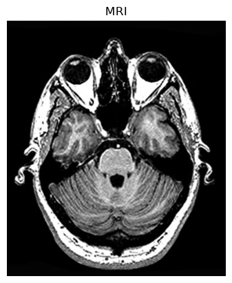

```python
mri = cv2.imread("mri.jpg", cv2.IMREAD_GRAYSCALE)
#convertir en float64
mri = mri.astype(np.float64)
mri = mri / 255.0
plt.imshow(mri, cmap='gray')
plt.title("MRI")
plt.axis("off")
plt.show()
```

```python
#Image sparse en seuillant les valeurs faibles
#Génération d'une image sparse
h, w = mri.shape[0], mri.shape[1]
sparse = np.zeros((h, w), dtype=np.float32)
num_points = 1000  #Nombre de pixels non nuls
x_coords = np.random.randint(0, w, num_points)
y_coords = np.random.randint(0, h, num_points)
sparse[y_coords, x_coords] = 255

sparse = sparse.astype(np.float64)
sparse = sparse / 255.0

image_const = np.zeros(mri.shape)
image_const[0:256, 0:256] = 0.8
image_const[0:256, 256:512] = 0.6
image_const[256:384, 0:512] = 0.4
image_const[384:512, 0:100] = 0.7
image_const[384:512, 100:512] = 0.8

image_const = image_const.astype(np.float64)
image_const = image_const / 255.0
```

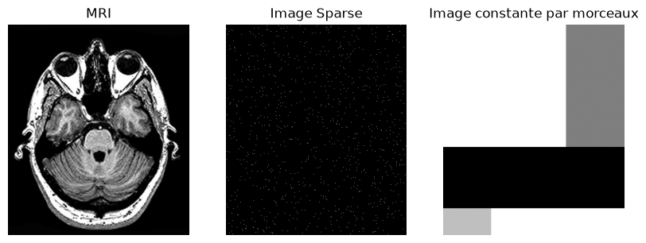

```python
plt.figure(figsize=(10, 5))
#afficher les 3 images dans la figure
plt.subplot(1, 3, 1)
plt.imshow(mri, cmap='gray')
plt.title("MRI")
plt.axis("off")

plt.subplot(1, 3, 2)
plt.imshow(sparse, cmap='gray')
plt.title("Image Sparse")
plt.axis("off")

plt.subplot(1, 3, 3)
plt.imshow(image_const, cmap='gray')
plt.title("Image constante par morceaux")
plt.axis("off")

plt.show()
```

**B)1) Convolution par un filtre gaussien de taille 15x15 puis bruitage avec bruit additif Gaussien, RSB 40dB**

```python
from scipy.ndimage import gaussian_filter
```

```python
def gen_noised(img, SNR):
  ps_i = np.mean(img ** 2)

  noise_variance = ps_i / (10 ** (SNR / 10))
  noise_std = np.sqrt(noise_variance)

  gaussian_noise = np.random.normal(0, noise_std, img.shape)
  return img + gaussian_noise, noise_variance
```

```
Variance du bruit 1.4370631600526545e-05
```

```
(np.float64(-0.5), np.float64(377.5), np.float64(439.5), np.float64(-0.5))
```

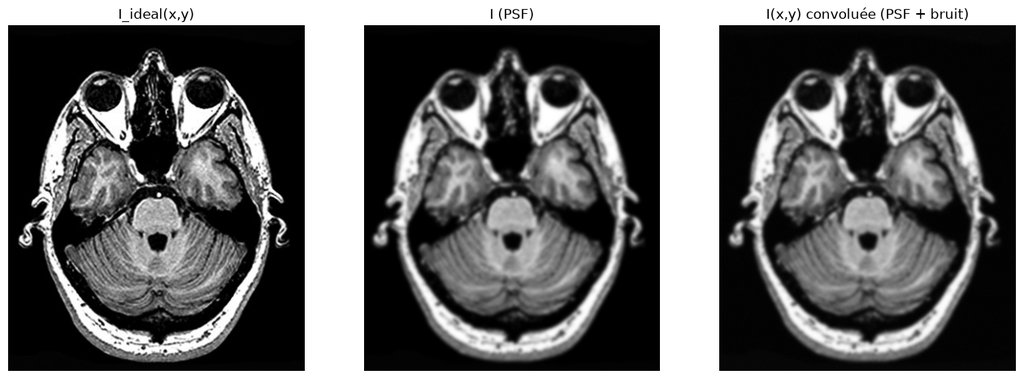

```python
#Créer un filtre gaussien 15x15 avec sigma = 2
h = np.zeros((15, 15))
h[7, 7] = 1
h = gaussian_filter(h, sigma=2)

#Normalisation (somme = 1)
h /= h.sum()


#Padding de h pour qu'il fasse la même taille que x
h_pad = np.pad(h, ((0, mri.shape[0]-h.shape[0]),(0,mri.shape[1]-h.shape[1])), 'constant')

#Roll de h (circshift)
h_roll = np.roll(h_pad, -h.shape[0]//2, axis=0)
h_roll = np.roll(h_roll, -h.shape[1]//2, axis=1)

#H = np.fft.fft2(h_roll)

#Valeurs propres de HBCCB
D = np.fft.fft2(h_roll, s=mri.shape)

X = np.fft.fft2(mri)

conv_X = D * X

mri_conv = np.real(np.fft.ifft2(conv_X))

#Bruiter

mri_noised, noise_variance = gen_noised(mri_conv,40)
print("Variance du bruit", noise_variance)

plt.figure(figsize=(16, 8))
plt.subplot(1, 3, 1)
plt.imshow(mri, cmap='gray')
plt.title("I_ideal(x,y)")
plt.axis("off")

plt.subplot(1, 3, 2)
plt.imshow(mri_conv, cmap='gray')
plt.title("I (PSF)")
plt.axis("off")

plt.subplot(1, 3, 3)
plt.imshow(mri_noised, cmap='gray')
plt.title("I(x,y) convoluée (PSF + bruit)")
plt.axis("off")
```

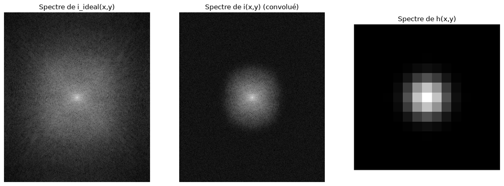

```python
#Visualiser la transformée de Fourier de i_ideal(x,y), de i(x,y) et de h(x,y)
i_ideal_spectrum = np.log(1 + np.abs(np.fft.fftshift(np.fft.fft2(mri))))
i_spectrum = np.log(1 + np.abs(np.fft.fftshift(np.fft.fft2(mri_noised))))
h_spectrum = np.log(1 + np.abs(np.fft.fftshift(np.fft.fft2(h))))
plt.figure(figsize=(16, 8))
#afficher les 3 images dans la figure
plt.subplot(1, 3, 1)
plt.imshow(i_ideal_spectrum, cmap='gray')
plt.title("Spectre de i_ideal(x,y)")
plt.axis("off")

plt.subplot(1, 3, 2)
plt.imshow(i_spectrum, cmap='gray')
plt.title("Spectre de i(x,y) (convolué)")
plt.axis("off")

plt.subplot(1, 3, 3)
plt.imshow(h_spectrum, cmap='gray')
plt.title("Spectre de h(x,y)")
plt.axis("off")

plt.show()
```

**Spectre de i_ideal(x, y)** : On observe une forte concentration d'énergie au centre (basses fréquences puisqu'on a fait un fftshift) ainsi qu'un dégradé progressif typique d'un image naturelle ou IRM. Peu de bruit visible à haute fréquence.

**Spectre de i(x, y)** : On observe un spectre nettement + bruité que celui de i_ideal(x, y). Les hautes fréquences sont fortement atténuées (décroissance en dehors du centre puis suppression totale). C'est le spectre de la convolution de i_ideal par h + un bruit additif gaussien

**Spectre de h(x, y)**: C'est le spectre d'un filtre gaussien dans le domaine fréquentiel. On observe une forme de cloche centrée, sans transitions brutales (contrairement au filtre passe bas idéal).

**Normalisation de Tikhonov :**

On va exprimer la solution de Tikhonov (estimation) dans le domaine de Fourier, sous des condition précises

La formule que l'on utilise est valable lorsque l'opérateur de convolution est circulant, ce qui permet de diagonaliser via la transformée de Fourier. Ici, D (calculée plus haut) est une matrice diagonale contenant les coefficients spectraux de l'opérateur de convolution.

conj(D) correspond au conjugué complexe de D. Dans le contexte de matrices diagonales, c'est équivalent à prendre le conjugué de chaque coefficient, ce qui permet de former le produit conj(D)*D

Le terme lambda * I (régularisation) assure la stabilisation de l'inversion, en atténant les effets du bruit et en régularisant la solution. C'est un compormis entre fidélité aux données et lisse régularisation.

En passant dans le domaine de Fourier, le problème matriciel de grande dimension se réduit à une inversion élément par élément sur les coefficients diagonaux, ce qui est beaucoup plus efficace en calcul.

```
(np.float64(-0.5), np.float64(377.5), np.float64(439.5), np.float64(-0.5))
```

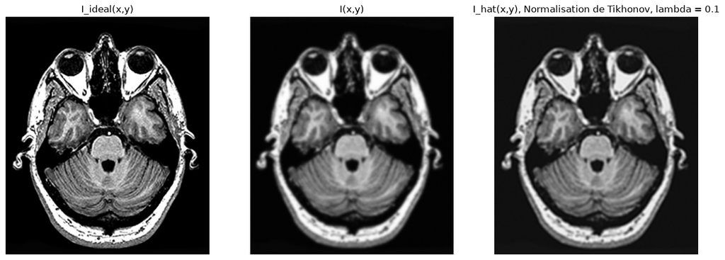

```python
#Normalisation de Tikhonov

def tikhonov(y, D, lmbda):

  D_T = np.conj(D)
  D_T_D = np.abs(D)**2

  estimation = np.fft.ifft2((D_T * np.fft.fft2(y)) / (D_T_D + lmbda)).real
  return estimation

i_hat = tikhonov(mri_noised, D, lmbda=0.1)
plt.figure(figsize=(16, 8))

plt.subplot(1, 3, 1)
plt.imshow(mri, cmap='gray')
plt.title("I_ideal(x,y)")
plt.axis("off")

plt.subplot(1, 3, 2)
plt.imshow(mri_noised, cmap='gray')
plt.title("I(x,y)")
plt.axis("off")

plt.subplot(1, 3, 3)
plt.imshow(i_hat, cmap='gray')
plt.title("I_hat(x,y), Normalisation de Tikhonov, lambda = 0.1")
plt.axis("off")
```

En faisant varier le paramètre de régularisation (lambda = 0.01)

```
(np.float64(-0.5), np.float64(377.5), np.float64(439.5), np.float64(-0.5))
```

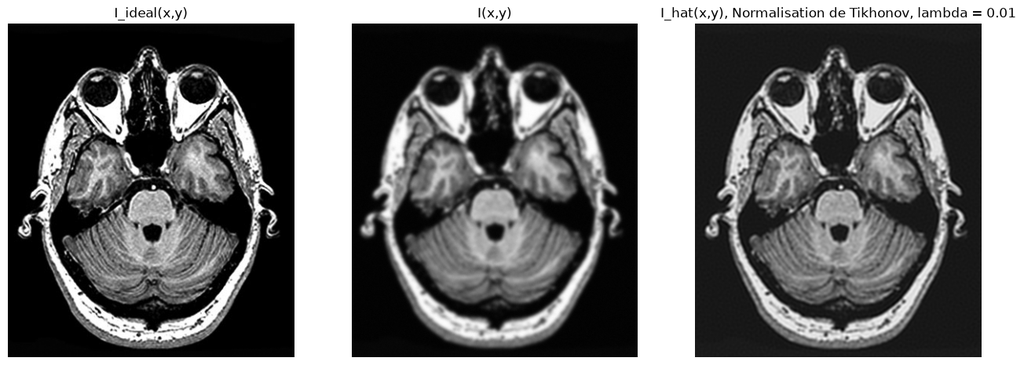

```python
i_hat2 = tikhonov(mri_noised, D, lmbda=0.01)
plt.figure(figsize=(16, 8))

plt.subplot(1, 3, 1)
plt.imshow(mri, cmap='gray')
plt.title("I_ideal(x,y)")
plt.axis("off")

plt.subplot(1, 3, 2)
plt.imshow(mri_noised, cmap='gray')
plt.title("I(x,y)")
plt.axis("off")

plt.subplot(1, 3, 3)
plt.imshow(i_hat2, cmap='gray')
plt.title("I_hat(x,y), Normalisation de Tikhonov, lambda = 0.01")
plt.axis("off")
```

On observe une meilleure restauration avec lambda = 0.01